# DenverEDA(2)

```python
import pandas as pd
import numpy as np
import matplotlib.pyplot as plt
import seaborn as sns
import warnings
warnings.filterwarnings('ignore')
import folium
```

```python
data=pd.read_csv("crime.csv")
```

```python
data.head(10)
```

|  | INCIDENT_ID | OFFENSE_ID | OFFENSE_CODE | OFFENSE_CODE_EXTENSION | OFFENSE_TYPE_ID | OFFENSE_CATEGORY_ID | FIRST_OCCURRENCE_DATE | LAST_OCCURRENCE_DATE | REPORTED_DATE | INCIDENT_ADDRESS | GEO_X | GEO_Y | GEO_LON | GEO_LAT | DISTRICT_ID | PRECINCT_ID | NEIGHBORHOOD_ID | IS_CRIME | IS_TRAFFIC |
| --- | --- | --- | --- | --- | --- | --- | --- | --- | --- | --- | --- | --- | --- | --- | --- | --- | --- | --- | --- |
| 0 | 2016376978 | 2016376978521300 | 5213 | 0 | weapon-unlawful-discharge-of | all-other-crimes | 6/15/2016 11:31:00 PM | NaN | 6/15/2016 11:31:00 PM | NaN | 3193983.0 | 1707251.0 | -104.809881 | 39.773188 | 5 | 521 | montbello | 1 | 0 |
| 1 | 20186000994 | 20186000994239900 | 2399 | 0 | theft-other | larceny | 10/11/2017 12:30:00 PM | 10/11/2017 4:55:00 PM | 1/29/2018 5:53:00 PM | NaN | 3201943.0 | 1711852.0 | -104.781434 | 39.785649 | 5 | 522 | gateway-green-valley-ranch | 1 | 0 |
| 2 | 20166003953 | 20166003953230500 | 2305 | 0 | theft-items-from-vehicle | theft-from-motor-vehicle | 3/4/2016 8:00:00 PM | 4/25/2016 8:00:00 AM | 4/26/2016 9:02:00 PM | 2932 S JOSEPHINE ST | 3152762.0 | 1667011.0 | -104.957381 | 39.663490 | 3 | 314 | wellshire | 1 | 0 |
| 3 | 201872333 | 201872333239900 | 2399 | 0 | theft-other | larceny | 1/30/2018 7:20:00 PM | NaN | 1/30/2018 10:29:00 PM | 705 S COLORADO BLVD | 3157162.0 | 1681320.0 | -104.941440 | 39.702698 | 3 | 312 | belcaro | 1 | 0 |
| 4 | 2017411405 | 2017411405230300 | 2303 | 0 | theft-shoplift | larceny | 6/22/2017 8:53:00 PM | NaN | 6/23/2017 4:09:00 PM | 2810 E 1ST AVE | 3153211.0 | 1686545.0 | -104.955370 | 39.717107 | 3 | 311 | cherry-creek | 1 | 0 |
| 5 | 201872837 | 201872837549900 | 5499 | 0 | traf-other | all-other-crimes | 1/31/2018 12:44:00 AM | NaN | 1/31/2018 1:29:00 AM | 2100 BLOCK E 17TH AVE | 3151310.0 | 1696020.0 | -104.961928 | 39.743149 | 6 | 622 | city-park-west | 1 | 0 |
| 6 | 20186001015 | 20186001015230400 | 2304 | 0 | theft-parts-from-vehicle | theft-from-motor-vehicle | 6/1/2017 12:15:00 PM | 1/26/2018 12:15:00 PM | 1/26/2018 12:24:00 PM | 995 N FEDERAL BLVD | 3133441.0 | 1692147.0 | -105.025543 | 39.732790 | 1 | 122 | villa-park | 1 | 0 |
| 7 | 201870628 | 201870628570700 | 5707 | 0 | criminal-trespassing | all-other-crimes | 1/30/2018 7:40:00 AM | NaN | 1/30/2018 10:33:00 AM | E SPEER BLVD / N GRANT ST | 3145202.0 | 1688799.0 | -104.983794 | 39.723424 | 3 | 311 | speer | 1 | 0 |
| 8 | 201870833 | 201870833540100 | 5401 | 0 | traffic-accident-hit-and-run | traffic-accident | 1/30/2018 9:10:00 AM | NaN | 1/30/2018 9:17:00 AM | W 13TH AVE / N CHEROKEE ST | 3142965.0 | 1693682.0 | -104.991650 | 39.736863 | 6 | 611 | civic-center | 0 | 1 |
| 9 | 20186001048 | 20186001048230500 | 2305 | 0 | theft-items-from-vehicle | theft-from-motor-vehicle | 1/31/2018 12:55:00 AM | 1/31/2018 6:55:00 AM | 1/31/2018 7:07:00 AM | 2828 N ZUNI ST | 3136231.0 | 1701209.0 | -105.015451 | 39.757627 | 1 | 113 | highland | 1 | 0 |

```python
data["OFFENSE_CODE"].nunique()
```

```
156
```

```python
data["INCIDENT_ID"].nunique()
```

```
472004
```

```python
data["OFFENSE_CODE_EXTENSION"].nunique()
```

```
6
```

```python
data["OFFENSE_TYPE_ID"].nunique()
```

```
201
```

```python
data["OFFENSE_ID"].nunique()
```

```
510619
```

```python
data["OFFENSE_CATEGORY_ID"].nunique()
```

```
15
```

```python
data.info()
```

```
<class 'pandas.core.frame.DataFrame'>
RangeIndex: 510619 entries, 0 to 510618
Data columns (total 19 columns):
INCIDENT_ID               510619 non-null int64
OFFENSE_ID                510619 non-null int64
OFFENSE_CODE              510619 non-null int64
OFFENSE_CODE_EXTENSION    510619 non-null int64
OFFENSE_TYPE_ID           510619 non-null object
OFFENSE_CATEGORY_ID       510619 non-null object
FIRST_OCCURRENCE_DATE     510619 non-null object
LAST_OCCURRENCE_DATE      161711 non-null object
REPORTED_DATE             510619 non-null object
INCIDENT_ADDRESS          460736 non-null object
GEO_X                     506406 non-null float64
GEO_Y                     506406 non-null float64
GEO_LON                   506406 non-null float64
GEO_LAT                   506406 non-null float64
DISTRICT_ID               510619 non-null int64
PRECINCT_ID               510619 non-null int64
NEIGHBORHOOD_ID           510619 non-null object
IS_CRIME                  510619 non-null int64
IS_TRAFFIC                510619 non-null int64
dtypes: float64(4), int64(8), object(7)
memory usage: 74.0+ MB
```

```python
data['IS_TRAFFIC'].value_counts()
```

```
0    377675
1    132944
Name: IS_TRAFFIC, dtype: int64
```

```python
data['IS_CRIME'].value_counts()
```

```
1    377947
0    132672
Name: IS_CRIME, dtype: int64
```

```python
data.head()
```

|  | INCIDENT_ID | OFFENSE_ID | OFFENSE_CODE | OFFENSE_CODE_EXTENSION | OFFENSE_TYPE_ID | OFFENSE_CATEGORY_ID | FIRST_OCCURRENCE_DATE | LAST_OCCURRENCE_DATE | REPORTED_DATE | INCIDENT_ADDRESS | GEO_X | GEO_Y | GEO_LON | GEO_LAT | DISTRICT_ID | PRECINCT_ID | NEIGHBORHOOD_ID | IS_CRIME | IS_TRAFFIC |
| --- | --- | --- | --- | --- | --- | --- | --- | --- | --- | --- | --- | --- | --- | --- | --- | --- | --- | --- | --- |
| 0 | 2016376978 | 2016376978521300 | 5213 | 0 | weapon-unlawful-discharge-of | all-other-crimes | 6/15/2016 11:31:00 PM | NaN | 6/15/2016 11:31:00 PM | NaN | 3193983.0 | 1707251.0 | -104.809881 | 39.773188 | 5 | 521 | montbello | 1 | 0 |
| 1 | 20186000994 | 20186000994239900 | 2399 | 0 | theft-other | larceny | 10/11/2017 12:30:00 PM | 10/11/2017 4:55:00 PM | 1/29/2018 5:53:00 PM | NaN | 3201943.0 | 1711852.0 | -104.781434 | 39.785649 | 5 | 522 | gateway-green-valley-ranch | 1 | 0 |
| 2 | 20166003953 | 20166003953230500 | 2305 | 0 | theft-items-from-vehicle | theft-from-motor-vehicle | 3/4/2016 8:00:00 PM | 4/25/2016 8:00:00 AM | 4/26/2016 9:02:00 PM | 2932 S JOSEPHINE ST | 3152762.0 | 1667011.0 | -104.957381 | 39.663490 | 3 | 314 | wellshire | 1 | 0 |
| 3 | 201872333 | 201872333239900 | 2399 | 0 | theft-other | larceny | 1/30/2018 7:20:00 PM | NaN | 1/30/2018 10:29:00 PM | 705 S COLORADO BLVD | 3157162.0 | 1681320.0 | -104.941440 | 39.702698 | 3 | 312 | belcaro | 1 | 0 |
| 4 | 2017411405 | 2017411405230300 | 2303 | 0 | theft-shoplift | larceny | 6/22/2017 8:53:00 PM | NaN | 6/23/2017 4:09:00 PM | 2810 E 1ST AVE | 3153211.0 | 1686545.0 | -104.955370 | 39.717107 | 3 | 311 | cherry-creek | 1 | 0 |

```python
data1=data
```

```python
cormat=data1.corr()
```

```python
cormat
```

|  | INCIDENT_ID | OFFENSE_ID | OFFENSE_CODE | OFFENSE_CODE_EXTENSION | GEO_X | GEO_Y | GEO_LON | GEO_LAT | DISTRICT_ID | PRECINCT_ID | IS_CRIME | IS_TRAFFIC |
| --- | --- | --- | --- | --- | --- | --- | --- | --- | --- | --- | --- | --- |
| INCIDENT_ID | 1.000000 | 1.000000 | -0.131009 | 0.030617 | -0.000421 | 0.000824 | 0.000166 | 0.004654 | 0.045950 | 0.049857 | 0.096901 | -0.097077 |
| OFFENSE_ID | 1.000000 | 1.000000 | -0.131009 | 0.030617 | -0.000421 | 0.000824 | 0.000166 | 0.004654 | 0.045950 | 0.049857 | 0.096901 | -0.097077 |
| OFFENSE_CODE | -0.131009 | -0.131009 | 1.000000 | -0.075783 | 0.010605 | 0.013781 | 0.010493 | -0.009232 | -0.042612 | -0.043024 | -0.572748 | 0.573559 |
| OFFENSE_CODE_EXTENSION | 0.030617 | 0.030617 | -0.075783 | 1.000000 | -0.003782 | -0.003004 | -0.003836 | 0.003934 | 0.017599 | 0.017826 | 0.210261 | -0.210552 |
| GEO_X | -0.000421 | -0.000421 | 0.010605 | -0.003782 | 1.000000 | 0.996753 | 0.999966 | -0.997481 | 0.043217 | 0.047802 | -0.020699 | 0.020899 |
| GEO_Y | 0.000824 | 0.000824 | 0.013781 | -0.003004 | 0.996753 | 1.000000 | 0.996767 | -0.989978 | 0.042594 | 0.046719 | -0.018053 | 0.018258 |
| GEO_LON | 0.000166 | 0.000166 | 0.010493 | -0.003836 | 0.999966 | 0.996767 | 1.000000 | -0.997052 | 0.045048 | 0.049750 | -0.020924 | 0.021123 |
| GEO_LAT | 0.004654 | 0.004654 | -0.009232 | 0.003934 | -0.997481 | -0.989978 | -0.997052 | 1.000000 | -0.032615 | -0.036783 | 0.020924 | -0.021132 |
| DISTRICT_ID | 0.045950 | 0.045950 | -0.042612 | 0.017599 | 0.043217 | 0.042594 | 0.045048 | -0.032615 | 1.000000 | 0.999150 | 0.075683 | -0.075960 |
| PRECINCT_ID | 0.049857 | 0.049857 | -0.043024 | 0.017826 | 0.047802 | 0.046719 | 0.049750 | -0.036783 | 0.999150 | 1.000000 | 0.075678 | -0.075957 |
| IS_CRIME | 0.096901 | 0.096901 | -0.572748 | 0.210261 | -0.020699 | -0.018053 | -0.020924 | 0.020924 | 0.075683 | 0.075678 | 1.000000 | -0.998617 |
| IS_TRAFFIC | -0.097077 | -0.097077 | 0.573559 | -0.210552 | 0.020899 | 0.018258 | 0.021123 | -0.021132 | -0.075960 | -0.075957 | -0.998617 | 1.000000 |

Visualising the correlation between different attributes

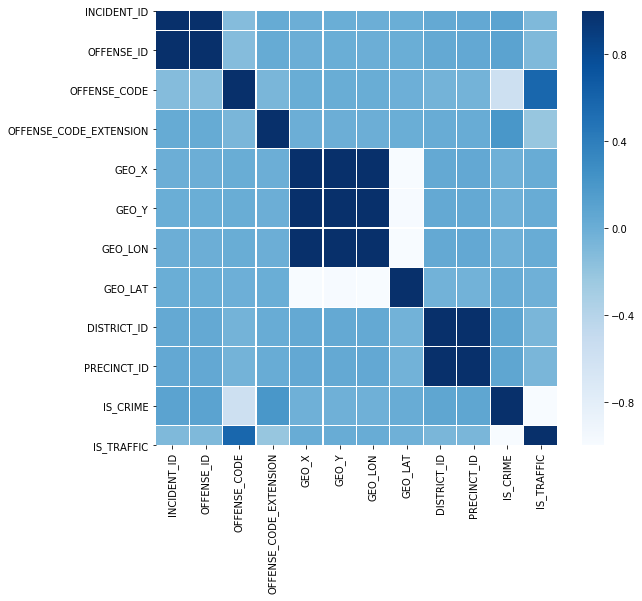

```python
f,ax = plt.subplots(figsize=(9,8))
sns.heatmap(cormat, ax=ax, cmap="Blues",linewidths=0.1)
```

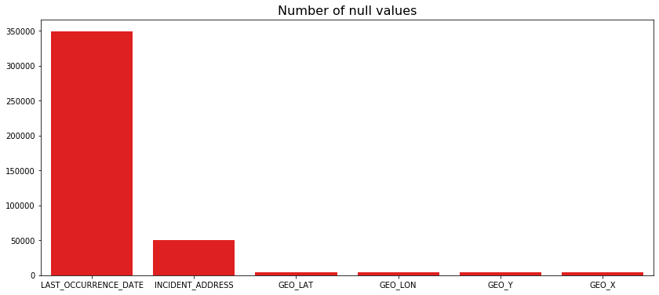

```python
x=data1.isnull().sum().sort_values(ascending=False)[:6].index
y=data1.isnull().sum().sort_values(ascending=False)[:6]
plt.figure(figsize=(14,6))
sns.barplot(x,y,color='r')
plt.title("Number of null values",size=16)
```

```python
data1.drop(columns={"INCIDENT_ADDRESS","LAST_OCCURRENCE_DATE"},inplace=True)
```

```python
data1.drop(columns={"IS_TRAFFIC"},inplace=True)
```

```python
df=data1["DISTRICT_ID"]
```

```python
df.nunique()
```

```
7
```

```python
ds=data1["PRECINCT_ID"]
```

```python
ds.nunique()
```

```
36
```

```python
dn=data1["NEIGHBORHOOD_ID"]
```

```python
dn.nunique()
```

```
78
```

```python
data1['FIRST_OCCURRENCE_DATE']=pd.to_datetime(data1['FIRST_OCCURRENCE_DATE'])
```

```python
data1['YEAR'] = data1['FIRST_OCCURRENCE_DATE'].dt.year
```

```python
data1['MONTH'] = data1['FIRST_OCCURRENCE_DATE'].dt.month
```

```python
data1['DAY'] = data1['FIRST_OCCURRENCE_DATE'].dt.day
```

```python
data1['HOUR'] = data1['FIRST_OCCURRENCE_DATE'].dt.hour
```

```python
data1
```

|  | INCIDENT_ID | OFFENSE_ID | OFFENSE_CODE | OFFENSE_CODE_EXTENSION | OFFENSE_TYPE_ID | OFFENSE_CATEGORY_ID | FIRST_OCCURRENCE_DATE | REPORTED_DATE | GEO_X | GEO_Y | GEO_LON | GEO_LAT | DISTRICT_ID | PRECINCT_ID | NEIGHBORHOOD_ID | IS_CRIME | YEAR | MONTH | DAY | HOUR |
| --- | --- | --- | --- | --- | --- | --- | --- | --- | --- | --- | --- | --- | --- | --- | --- | --- | --- | --- | --- | --- |
| 0 | 2016376978 | 2016376978521300 | 5213 | 0 | weapon-unlawful-discharge-of | all-other-crimes | 2016-06-15 23:31:00 | 6/15/2016 11:31:00 PM | 3193983.0 | 1707251.0 | -104.809881 | 39.773188 | 5 | 521 | montbello | 1 | 2016 | 6 | 15 | 23 |
| 1 | 20186000994 | 20186000994239900 | 2399 | 0 | theft-other | larceny | 2017-10-11 12:30:00 | 1/29/2018 5:53:00 PM | 3201943.0 | 1711852.0 | -104.781434 | 39.785649 | 5 | 522 | gateway-green-valley-ranch | 1 | 2017 | 10 | 11 | 12 |
| 2 | 20166003953 | 20166003953230500 | 2305 | 0 | theft-items-from-vehicle | theft-from-motor-vehicle | 2016-03-04 20:00:00 | 4/26/2016 9:02:00 PM | 3152762.0 | 1667011.0 | -104.957381 | 39.663490 | 3 | 314 | wellshire | 1 | 2016 | 3 | 4 | 20 |
| 3 | 201872333 | 201872333239900 | 2399 | 0 | theft-other | larceny | 2018-01-30 19:20:00 | 1/30/2018 10:29:00 PM | 3157162.0 | 1681320.0 | -104.941440 | 39.702698 | 3 | 312 | belcaro | 1 | 2018 | 1 | 30 | 19 |
| 4 | 2017411405 | 2017411405230300 | 2303 | 0 | theft-shoplift | larceny | 2017-06-22 20:53:00 | 6/23/2017 4:09:00 PM | 3153211.0 | 1686545.0 | -104.955370 | 39.717107 | 3 | 311 | cherry-creek | 1 | 2017 | 6 | 22 | 20 |
| ... | ... | ... | ... | ... | ... | ... | ... | ... | ... | ... | ... | ... | ... | ... | ... | ... | ... | ... | ... | ... |
| 510614 | 2018836985 | 2018836985549900 | 5499 | 0 | traf-other | all-other-crimes | 2018-12-11 18:06:00 | 12/11/2018 6:22:00 PM | 3155222.0 | 1694846.0 | -104.948043 | 39.739862 | 2 | 213 | congress-park | 1 | 2018 | 12 | 11 | 18 |
| 510615 | 20188058998 | 20188058998260201 | 2602 | 1 | theft-fail-return-rent-veh | white-collar-crime | 2018-11-19 16:00:00 | 12/14/2018 3:56:00 PM | 3225444.0 | 1730468.0 | -104.697230 | 39.836210 | 7 | 759 | dia | 1 | 2018 | 11 | 19 | 16 |
| 510616 | 2018848306 | 2018848306544100 | 5441 | 0 | traffic-accident | traffic-accident | 2018-12-16 17:37:00 | 12/16/2018 6:43:00 PM | 3157417.0 | 1675782.0 | -104.940655 | 39.687491 | 3 | 312 | cory-merrill | 0 | 2018 | 12 | 16 | 17 |
| 510617 | 2018831000 | 2018831000549900 | 5499 | 0 | traf-other | all-other-crimes | 2018-12-09 05:21:00 | 12/9/2018 6:15:00 AM | 3132244.0 | 1694350.0 | -105.029758 | 39.738855 | 1 | 122 | west-colfax | 1 | 2018 | 12 | 9 | 5 |
| 510618 | 20186012081 | 20186012081230400 | 2304 | 0 | theft-parts-from-vehicle | theft-from-motor-vehicle | 2018-12-12 16:35:00 | 12/12/2018 4:42:00 PM | 3158445.0 | 1672408.0 | -104.937077 | 39.678211 | 3 | 314 | university-hills | 1 | 2018 | 12 | 12 | 16 |

510619 rows × 20 columns

```python
a_list=data1["YEAR"].tolist()
```

```python
a=pd.DataFrame()
```

```python
a['YEAR']=a_list
```

Which year has the highest number of crimes?

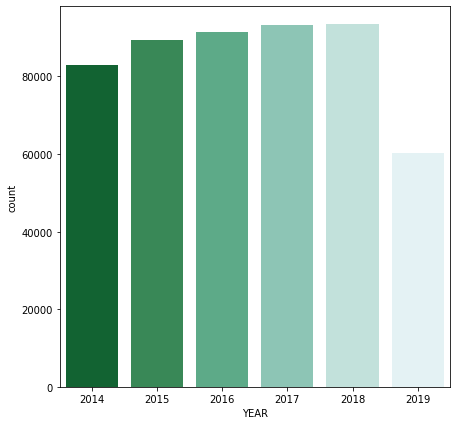

```python
fig, ax=plt.subplots(figsize=(7,7))
sns.countplot(a['YEAR'],palette='BuGn_r')
```

2018 has the highest number of crimes

Which month has the highest number of crimes?

```python
b_list=data1["MONTH"].tolist()
b=pd.DataFrame()
b["MONTH"]=b_list
```

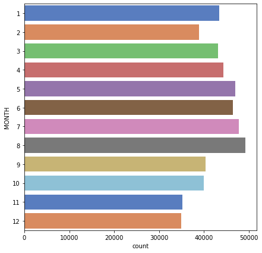

```python
fig, ax=plt.subplots(figsize=(7,7))
sns.countplot(y=b["MONTH"],palette='muted')
```

Which day of the month has the highest number of crimes ?

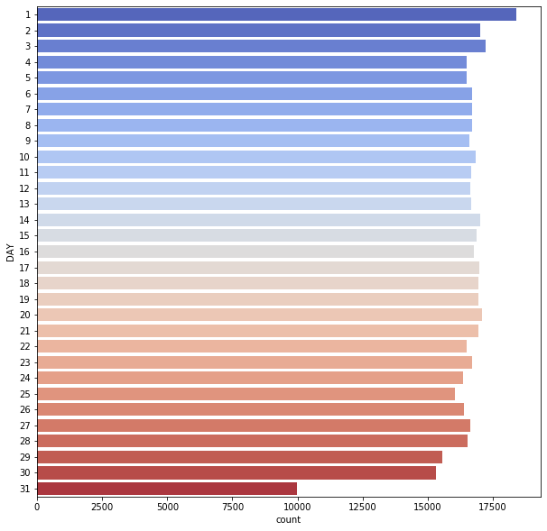

```python
c_list=data1["DAY"].tolist()
c=pd.DataFrame()
c["DAY"]=c_list

fig, ax=plt.subplots(figsize=(10,10))
sns.countplot(y=c["DAY"],palette='coolwarm')
```

The first day of the month has the highest number of crimes

Which hour of the day is most dangerous?

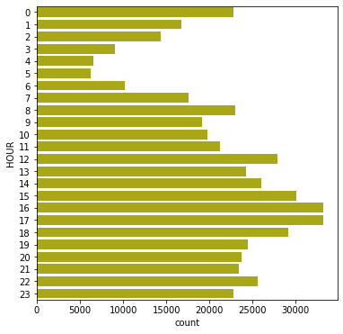

```python
d_list=data1["HOUR"].tolist()
d=pd.DataFrame()
d["HOUR"]=d_list

fig, ax=plt.subplots(figsize=(6,6))
sns.countplot(y=d["HOUR"],color='y')
```

The 16th and 17th hour of the day is most dangerous

Which district has had the highest number of crimes till date?

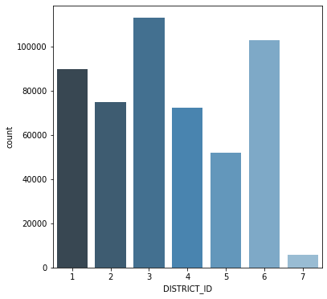

```python
e_list=data1["DISTRICT_ID"].tolist()
e=pd.DataFrame()
e["DISTRICT_ID"]=e_list
fig,ax=plt.subplots(figsize=(6,6))
sns.countplot(e["DISTRICT_ID"],palette='Blues_d')
```

The 3rd district has the highest number of crimes

Which Precinct is most dangerous?

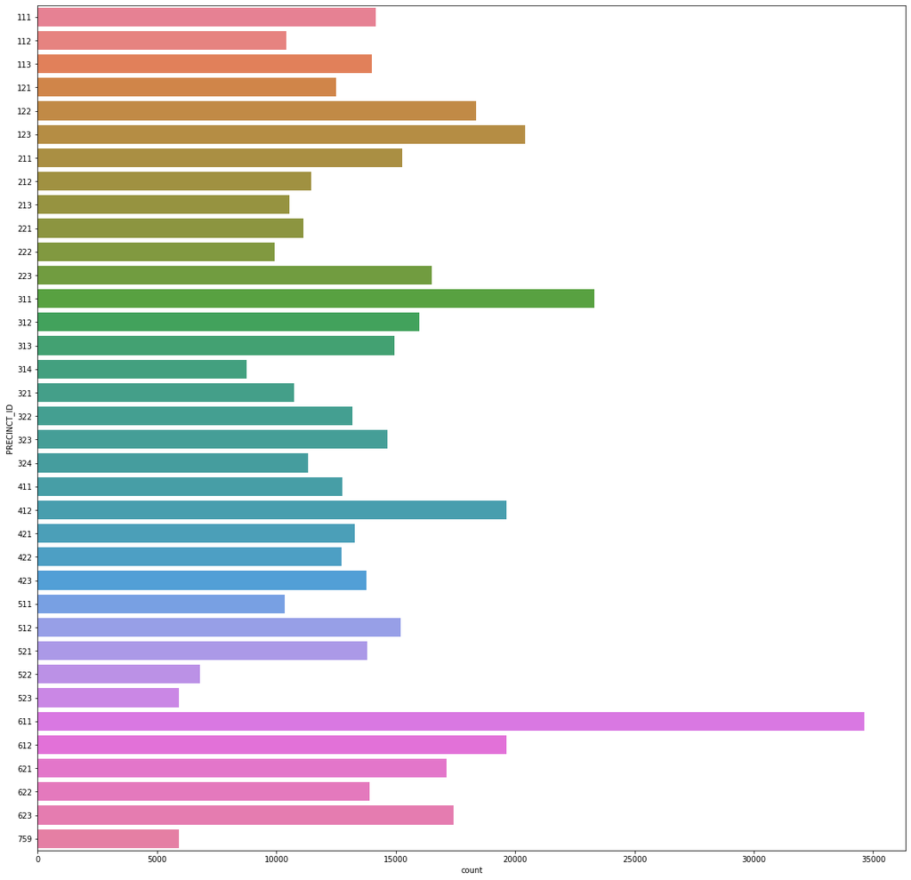

```python
f_list=data1["PRECINCT_ID"].tolist()
f=pd.DataFrame()
f["PRECINCT_ID"]=f_list
fig,ax=plt.subplots(figsize=(20,20))
sns.countplot(y=f["PRECINCT_ID"],palette='husl')
```

Precinct 611 is most dangerous

Which district has the highest number of precincts with crime?

```python
dv=data1.groupby('DISTRICT_ID')['PRECINCT_ID'].nunique()
```

```python
dv
```

```
DISTRICT_ID
1     7
2     6
3    10
4     5
5     5
6     5
7     1
Name: PRECINCT_ID, dtype: int64
```

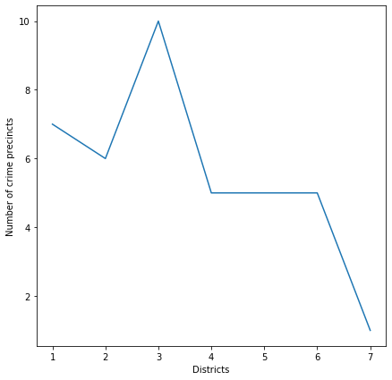

```python
g_list=dv
g=pd.DataFrame()
g["DISTRICT_ID"]=g_list
fig,ax=plt.subplots(figsize=(7,7))
sns.lineplot(data=dv)
plt.xlabel("Districts")
plt.ylabel("Number of crime precincts")
```

District 3 has the most number of crime precincts

Which crime is most prevalent in wich hour?

```python
pivot=data1.pivot_table(index='OFFENSE_CATEGORY_ID',columns='HOUR',aggfunc='size')
```

```python
pivot
```

| HOUR OFFENSE_CATEGORY_ID | 0 | 1 | 2 | 3 | 4 | 5 | 6 | 7 | 8 | 9 | ... | 14 | 15 | 16 | 17 | 18 | 19 | 20 | 21 | 22 | 23 |
| --- | --- | --- | --- | --- | --- | --- | --- | --- | --- | --- | --- | --- | --- | --- | --- | --- | --- | --- | --- | --- | --- |
| aggravated-assault | 756 | 865 | 774 | 395 | 241 | 193 | 178 | 214 | 224 | 279 | ... | 483 | 553 | 570 | 572 | 623 | 717 | 743 | 773 | 776 | 749 |
| all-other-crimes | 5487 | 4592 | 3506 | 2252 | 1471 | 900 | 1132 | 2005 | 2963 | 2583 | ... | 4269 | 5093 | 5980 | 4994 | 4846 | 4659 | 4743 | 4727 | 5951 | 6792 |
| arson | 62 | 30 | 35 | 33 | 27 | 23 | 16 | 22 | 26 | 14 | ... | 17 | 14 | 28 | 28 | 38 | 27 | 28 | 33 | 39 | 34 |
| auto-theft | 1350 | 659 | 616 | 439 | 439 | 694 | 1078 | 1320 | 1162 | 693 | ... | 819 | 954 | 1132 | 1662 | 1701 | 1619 | 1915 | 2027 | 2295 | 1445 |
| burglary | 1173 | 795 | 798 | 858 | 672 | 561 | 677 | 1107 | 1564 | 1049 | ... | 894 | 1069 | 1207 | 1738 | 1593 | 1148 | 1071 | 1120 | 1178 | 872 |
| drug-alcohol | 1117 | 924 | 692 | 465 | 280 | 152 | 185 | 416 | 733 | 1082 | ... | 2317 | 2615 | 3706 | 2429 | 2068 | 1883 | 1512 | 1378 | 1501 | 1365 |
| larceny | 1800 | 1085 | 791 | 565 | 471 | 460 | 734 | 1228 | 2345 | 2082 | ... | 3487 | 3745 | 3657 | 3817 | 3298 | 2652 | 2229 | 1863 | 1731 | 1515 |
| murder | 25 | 22 | 22 | 10 | 14 | 6 | 6 | 4 | 3 | 5 | ... | 11 | 7 | 7 | 12 | 19 | 20 | 22 | 22 | 22 | 22 |
| other-crimes-against-persons | 1319 | 1369 | 1100 | 571 | 424 | 316 | 424 | 605 | 746 | 835 | ... | 1135 | 1255 | 1278 | 1293 | 1375 | 1387 | 1435 | 1367 | 1412 | 1313 |
| public-disorder | 3539 | 2409 | 1942 | 1261 | 829 | 711 | 983 | 1411 | 2018 | 1897 | ... | 2133 | 2379 | 2484 | 2821 | 2736 | 2751 | 2909 | 2959 | 3353 | 2907 |
| robbery | 364 | 394 | 420 | 221 | 146 | 131 | 117 | 93 | 119 | 153 | ... | 266 | 256 | 312 | 304 | 332 | 382 | 409 | 483 | 449 | 432 |
| sexual-assault | 485 | 233 | 242 | 154 | 106 | 80 | 88 | 74 | 195 | 117 | ... | 133 | 159 | 140 | 144 | 181 | 171 | 231 | 217 | 260 | 258 |
| theft-from-motor-vehicle | 2654 | 1325 | 1011 | 745 | 587 | 578 | 886 | 1183 | 1906 | 1505 | ... | 1249 | 1410 | 1658 | 2072 | 2278 | 2019 | 2349 | 2459 | 2990 | 2180 |
| traffic-accident | 2132 | 2042 | 2402 | 1072 | 816 | 1383 | 3639 | 7758 | 8314 | 6439 | ... | 8337 | 10110 | 10606 | 10937 | 7737 | 4851 | 3965 | 3858 | 3552 | 2801 |
| white-collar-crime | 542 | 59 | 42 | 35 | 28 | 30 | 75 | 156 | 717 | 452 | ... | 442 | 407 | 392 | 346 | 290 | 197 | 187 | 140 | 119 | 121 |

15 rows × 24 columns

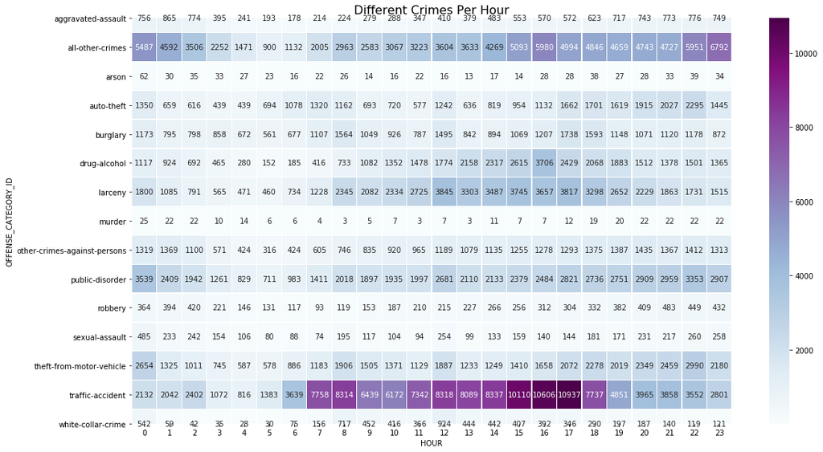

```python
fig,ax = plt.subplots(figsize=(18,10))
sns.heatmap(pivot,ax=ax,cmap="BuPu",annot=True,fmt="",linewidth=0.3)
plt.title("Different Crimes Per Hour",size=16)
```

Which crime is most prevalent on which day?

```python
pivot1=data1.pivot_table(index="OFFENSE_CATEGORY_ID",columns="DAY",aggfunc="size")
```

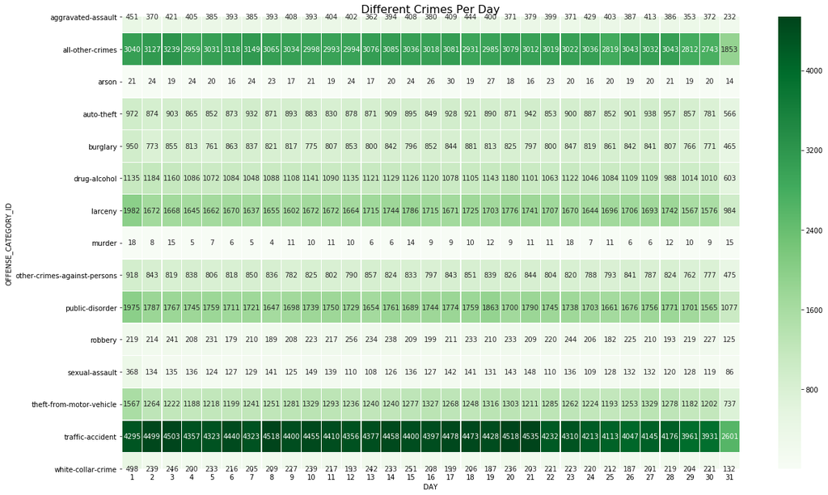

```python
fig,ax=plt.subplots(figsize=(20,12))
sns.heatmap(pivot1,ax=ax,cmap='Greens',linewidths=0.3,annot=True,fmt="")
plt.title("Different Crimes Per Day",size=16)
```

```python
pivot2=data1.pivot_table(index='OFFENSE_CATEGORY_ID',columns='MONTH',aggfunc='size')
```

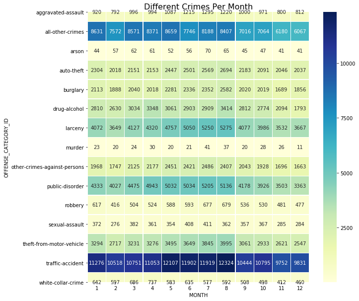

```python
fig,ax=plt.subplots(figsize=(10,10))
sns.heatmap(pivot2,ax=ax,cmap='YlGnBu',linewidths=0.3,annot=True,fmt="")
plt.title("Different Crimes Per Month",size=16)
```

Which neighborhood is most dangerous?

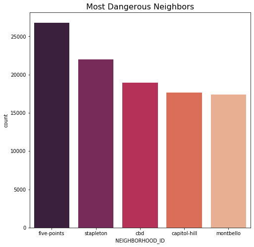

```python
plt.figure(figsize=(8,8))
sns.countplot(x="NEIGHBORHOOD_ID",data=data1,order=data1["NEIGHBORHOOD_ID"].value_counts()[:5].index,palette='rocket')
plt.title('Most Dangerous Neighbors',fontsize=16)
```

five-points is the most dangerous neighborhood

Which is neighborhood is the safest?

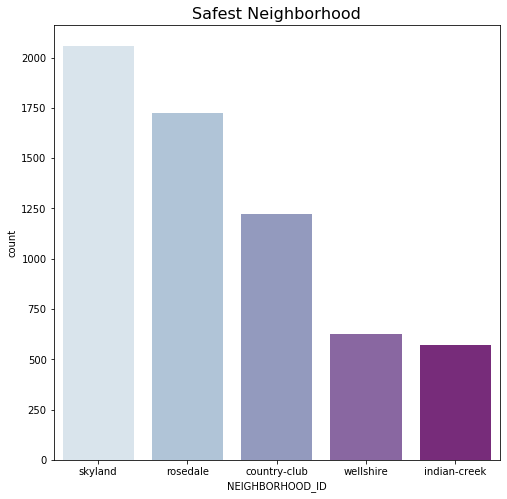

```python
plt.figure(figsize=(8,8))
sns.countplot(x="NEIGHBORHOOD_ID",data=data1,order=data1["NEIGHBORHOOD_ID"].value_counts()[-5:].index,palette="BuPu")
plt.title('Safest Neighborhood',fontsize=16)
```

Crime trends each year in each district

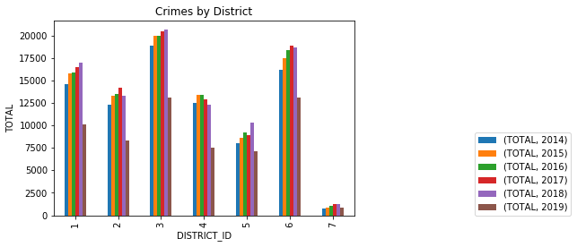

```python
temp=data1[['FIRST_OCCURRENCE_DATE','DISTRICT_ID']].groupby([data1.FIRST_OCCURRENCE_DATE.dt.year, data1.DISTRICT_ID]).agg('count')
temp=temp.drop(labels='FIRST_OCCURRENCE_DATE',axis=1)
temp.columns=['TOTAL']
temp=temp.unstack(level=0)
temp.plot(kind='bar',stacked=False)
plt.ylabel('TOTAL')
plt.title('Crimes by District')
plt.legend(loc=(1.4,0))
plt.show()
```

```python
offense=pd.read_csv('offense_codes.csv')
```

```python
offense.head()
```

|  | OFFENSE_CODE | OFFENSE_CODE_EXTENSION | OFFENSE_TYPE_ID | OFFENSE_TYPE_NAME | OFFENSE_CATEGORY_ID | OFFENSE_CATEGORY_NAME | IS_CRIME | IS_TRAFFIC |
| --- | --- | --- | --- | --- | --- | --- | --- | --- |
| 0 | 2804 | 1 | stolen-property-possession | Possession of stolen property | all-other-crimes | All Other Crimes | 1 | 0 |
| 1 | 2804 | 2 | fraud-possess-financial-device | Possession of a financial device | all-other-crimes | All Other Crimes | 1 | 0 |
| 2 | 2901 | 0 | damaged-prop-bus | Damaged business property | public-disorder | Public Disorder | 1 | 0 |
| 3 | 2902 | 0 | criminal-mischief-private | Criminal mischief to private property | public-disorder | Public Disorder | 1 | 0 |
| 4 | 2903 | 0 | criminal-mischief-public | Criminal mischief to public property | public-disorder | Public Disorder | 1 | 0 |

```python
offense1=offense
```

```python
offense1.corr()
```

|  | OFFENSE_CODE | OFFENSE_CODE_EXTENSION | IS_CRIME | IS_TRAFFIC |
| --- | --- | --- | --- | --- |
| OFFENSE_CODE | 1.000000 | 0.092544 | -0.165622 | 0.192404 |
| OFFENSE_CODE_EXTENSION | 0.092544 | 1.000000 | -0.080470 | 0.050998 |
| IS_CRIME | -0.165622 | -0.080470 | 1.000000 | -0.863065 |
| IS_TRAFFIC | 0.192404 | 0.050998 | -0.863065 | 1.000000 |

```python
offense1.drop(columns={'IS_TRAFFIC'},inplace=True)
```

```python
offense1['OFFENSE_CATEGORY_ID'].value_counts()
```

```
all-other-crimes                107
drug-alcohol                     30
white-collar-crime               29
public-disorder                  27
larceny                          15
other-crimes-against-persons     14
robbery                          13
aggravated-assault               13
sexual-assault                   13
burglary                         11
murder                            9
traffic-accident                  6
arson                             5
auto-theft                        4
theft-from-motor-vehicle          3
Name: OFFENSE_CATEGORY_ID, dtype: int64
```

Which crime category has the highest frequency?

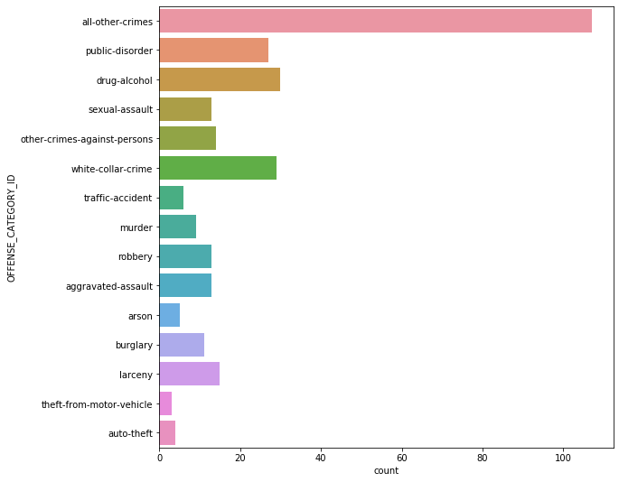

```python
h_list=offense1["OFFENSE_CATEGORY_ID"].tolist()
h=pd.DataFrame()
h["OFFENSE_CATEGORY_ID"]=h_list
fig,ax=plt.subplots(figsize=(9,9))
sns.countplot(y=h["OFFENSE_CATEGORY_ID"])
```

```python
offense1.drop(columns={"OFFENSE_CATEGORY_NAME"},inplace=True)
```

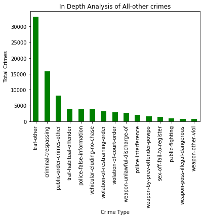

```python
temp=data1[data1['OFFENSE_CATEGORY_ID']=='all-other-crimes'].OFFENSE_TYPE_ID.value_counts().head(15).plot(kind='bar',color='g')
plt.title('In Depth Analysis of All-other crimes')
plt.xlabel('Crime Type')
plt.ylabel('Total Crimes')
plt.show()
```

To Conclude the Ananlysis we plot a heatmap using folium over the regions in Denver where Crimes Related to drug and alcohol is the Most.

```python
from folium import plugins
def heatmap_creator(*args):
    check_for_coordinates=data1['GEO_LAT'].isna()|data1['GEO_LON'].isna()
    temp=data1[~check_for_coordinates]
    for item in args:
        a,b=item
        temp=temp[temp[a]==b]
        print(str(a)+': '+str(b))
    hm_prep=temp[['GEO_LAT','GEO_LON']].as_matrix()
    m = folium.Map(location=[39.73,-104.90], tiles='Stamen Toner',zoom_start=11, control_scale=True)
    m.add_children(plugins.HeatMap(hm_prep,radius=15,gradient={.4: 'blue', .65: 'lime', 1: 'red'}))
    folium.TileLayer('openstreetmap').add_to(m)


    folium.LayerControl().add_to(m)

    return display(m)
```

```python
heatmap_creator(('OFFENSE_CATEGORY_ID','drug-alcohol'))
```

```
OFFENSE_CATEGORY_ID: drug-alcohol
```

[interactive chart not shown]

Thank You